# Project: Communicate Data Findings [Fifa GoBike System Data]

- Introduction
- Data Wrangling
- Feature Engineering
- Univariate Exploration
- Bivariate Exploration
- Multivariate Exploration
- Conclusions

## Introduction

### Dataset Description

> Fifa GoBike System Data includes information about individual rides made in a bike-sharing system covering the greater San Francisco Bay area.

```python
df = pd.read_csv(r"C:\Users\zizo\Downloads\Data Visualization\201902-fordgobike-tripdata.csv")
df.head()
```

|  | duration_sec | start_time | end_time | start_station_id | start_station_name | start_station_latitude | start_station_longitude | end_station_id | end_station_name | end_station_latitude | end_station_longitude | bike_id | user_type | member_birth_year | member_gender | bike_share_for_all_trip |
| --- | --- | --- | --- | --- | --- | --- | --- | --- | --- | --- | --- | --- | --- | --- | --- | --- |
| 0 | 52185 | 2019-02-28 17:32:10.1450 | 2019-03-01 08:01:55.9750 | 21.0 | Montgomery St BART Station (Market St at 2nd St) | 37.789625 | -122.400811 | 13.0 | Commercial St at Montgomery St | 37.794231 | -122.402923 | 4902 | Customer | 1984.0 | Male | No |
| 1 | 42521 | 2019-02-28 18:53:21.7890 | 2019-03-01 06:42:03.0560 | 23.0 | The Embarcadero at Steuart St | 37.791464 | -122.391034 | 81.0 | Berry St at 4th St | 37.775880 | -122.393170 | 2535 | Customer | NaN | NaN | No |
| 2 | 61854 | 2019-02-28 12:13:13.2180 | 2019-03-01 05:24:08.1460 | 86.0 | Market St at Dolores St | 37.769305 | -122.426826 | 3.0 | Powell St BART Station (Market St at 4th St) | 37.786375 | -122.404904 | 5905 | Customer | 1972.0 | Male | No |
| 3 | 36490 | 2019-02-28 17:54:26.0100 | 2019-03-01 04:02:36.8420 | 375.0 | Grove St at Masonic Ave | 37.774836 | -122.446546 | 70.0 | Central Ave at Fell St | 37.773311 | -122.444293 | 6638 | Subscriber | 1989.0 | Other | No |
| 4 | 1585 | 2019-02-28 23:54:18.5490 | 2019-03-01 00:20:44.0740 | 7.0 | Frank H Ogawa Plaza | 37.804562 | -122.271738 | 222.0 | 10th Ave at E 15th St | 37.792714 | -122.248780 | 4898 | Subscriber | 1974.0 | Male | Yes |

## Data Cleaning

> Converting the start time, end time from string to datetime.

> Converting bike_share_for_all_trip from string to boolean.

> Handling the NaN Values

```python
df.describe()
```

|  | duration_sec | start_station_id | start_station_latitude | start_station_longitude | end_station_id | end_station_latitude | end_station_longitude | bike_id | member_birth_year |
| --- | --- | --- | --- | --- | --- | --- | --- | --- | --- |
| count | 174952.000000 | 174952.000000 | 174952.000000 | 174952.000000 | 174952.000000 | 174952.000000 | 174952.000000 | 174952.000000 | 174952.000000 |
| mean | 704.002744 | 139.002126 | 37.771220 | -122.351760 | 136.604486 | 37.771414 | -122.351335 | 4482.587555 | 1984.803135 |
| std | 1642.204905 | 111.648819 | 0.100391 | 0.117732 | 111.335635 | 0.100295 | 0.117294 | 1659.195937 | 10.118731 |
| min | 61.000000 | 3.000000 | 37.317298 | -122.453704 | 3.000000 | 37.317298 | -122.453704 | 11.000000 | 1878.000000 |
| 25% | 323.000000 | 47.000000 | 37.770407 | -122.411901 | 44.000000 | 37.770407 | -122.411647 | 3799.000000 | 1980.000000 |
| 50% | 510.000000 | 104.000000 | 37.780760 | -122.398279 | 101.000000 | 37.781010 | -122.397437 | 4960.000000 | 1987.000000 |
| 75% | 789.000000 | 239.000000 | 37.797320 | -122.283093 | 238.000000 | 37.797673 | -122.286533 | 5505.000000 | 1992.000000 |
| max | 84548.000000 | 398.000000 | 37.880222 | -121.874119 | 398.000000 | 37.880222 | -121.874119 | 6645.000000 | 2001.000000 |

## Feature Engineering

> Creating col for uses' ages.

> Creating columns for Start day, weekday, and hour

> Creating a new column that check if the end station is the same as the start station or not

## Univariate Exploration

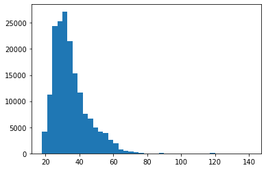

```python
bins_age = get_bins(df['age'].max(), df['age'].min(), len(df['age']))
plt.hist(data=df, x='age', bins=bins_age);
```

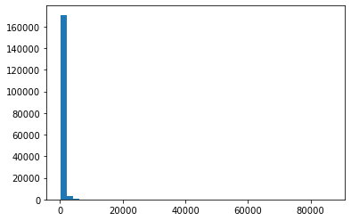

```python
bins_duration = get_bins(df['duration_sec'].max(), df['duration_sec'].min(), len(df['duration_sec']))
plt.hist(data=df, x='duration_sec', bins=bins_duration);
```

#### We see here that most of the data on about 5000, so we will pass 3*std alternative of the max value to remove the outliers from the curve

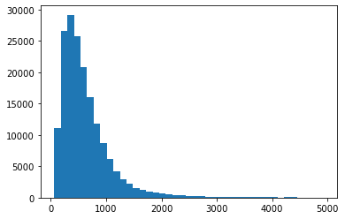

```python
maxValue = 3*df['duration_sec'].std()
bins_duration = get_bins(maxValue, df['duration_sec'].min(), len(df['duration_sec']))
plt.hist(data=df, x='duration_sec', bins=bins_duration);
```

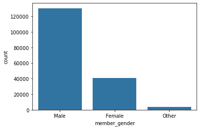

```python
base_color = sb.color_palette()[0]
sb.countplot(data = df, x='member_gender', color=base_color, order=['Male', 'Female', 'Other'])
```

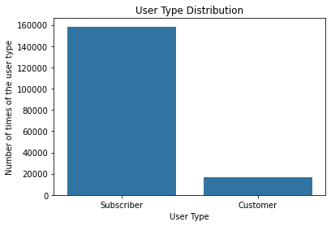

```python
sb.countplot(data = df, x='user_type', color=base_color, order=['Subscriber', 'Customer'])
plt.xlabel("User Type")
plt.ylabel("Number of times of the user type")
plt.title("User Type Distribution");
```

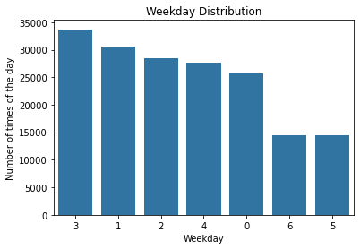

```python
weekdays_order = df['start_weekday'].value_counts().index
sb.countplot(data = df, x='start_weekday', color=base_color, order=weekdays_order)
plt.xlabel("Weekday")
plt.ylabel("Number of times of the day")
plt.title("Weekday Distribution");
```

#### We saw here that 3 (thursday) is the most day of rides

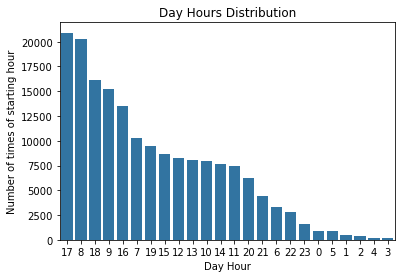

```python
hours_order = df['start_hour'].value_counts().index
sb.countplot(data = df, x='start_hour', color=base_color, order=hours_order)
plt.xlabel("Day Hour")
plt.ylabel("Number of times of starting hour")
plt.title("Day Hours Distribution");
```

#### We saw here that 8, 9 and 17, 18 is the most hour for starting rides, which expected because its work times.

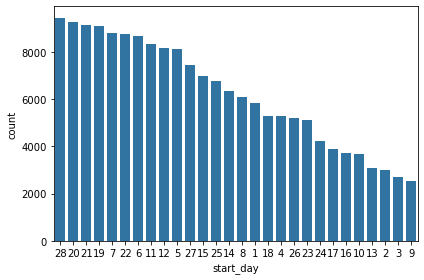

```python
days_order = df['start_day'].value_counts().index
sb.countplot(data = df, x='start_day', color=base_color, order=days_order)
plt.tight_layout()
```

#### Here, we saw that the last days of February especially 28 is the most day of rides.

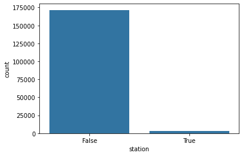

```python
sb.countplot(data = df, x='station', color=base_color)
```

#### Here, we saw that the end station usually is not the same as the start station.

## Bivariate Exploration

### Distribution of duration_sec VS day hour

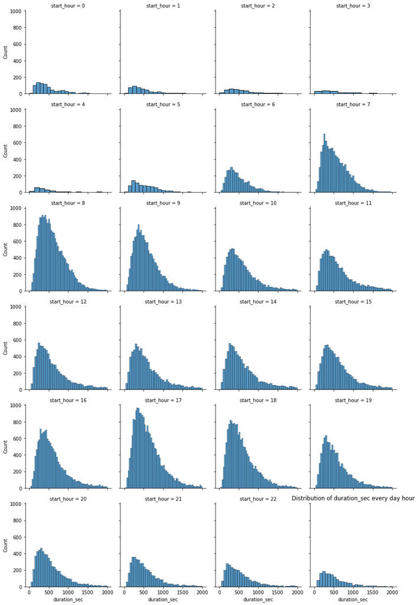

```python
g = sb.FacetGrid(data=df, col='start_hour', col_wrap=4)
g.map(sb.histplot, 'duration_sec',  binrange=(0, 2000));
plt.title("Distribution of duration_sec every day hour");
```

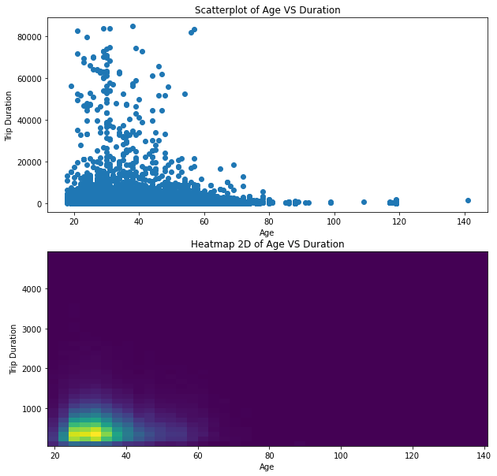

```python
fig, ax = plt.subplots(2, 1, figsize=(10, 10))

ax[0].scatter(data=df, x='age', y='duration_sec')
ax[0].set_xlabel("Age")
ax[0].set_ylabel("Trip Duration")
ax[0].set_title("Scatterplot of Age VS Duration")

bins_x = get_bins(df['age'].max(), df['age'].min(), len(df['age']))
bins_y = get_bins(3*df['duration_sec'].std(), df['duration_sec'].min(), len(df['duration_sec']))

ax[1].hist2d(data=df, x='age', y='duration_sec', bins=[bins_x, bins_y]);
ax[1].set_xlabel("Age")
ax[1].set_ylabel("Trip Duration")
ax[1].set_title("Heatmap 2D of Age VS Duration");
```

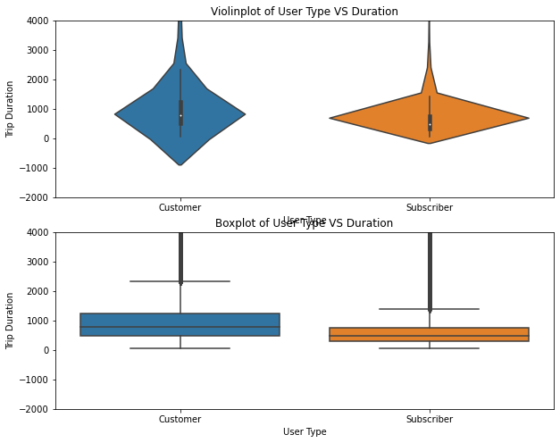

```python
fig, ax = plt.subplots(2, 1, figsize=(10, 8))
sb.violinplot(ax = ax[0], data=df, x='user_type', y='duration_sec');
ax[0].set_ylim((-2000, 4000))
ax[0].set_xlabel("User Type")
ax[0].set_ylabel("Trip Duration")
ax[0].set_title("Violinplot of User Type VS Duration")

sb.boxplot(ax = ax[1], data=df, x='user_type', y='duration_sec');
ax[1].set_ylim((-2000, 4000))
ax[1].set_xlabel("User Type")
ax[1].set_ylabel("Trip Duration")
ax[1].set_title("Boxplot of User Type VS Duration");
```

#### We can see that on average that customers do longer trips than subscribers

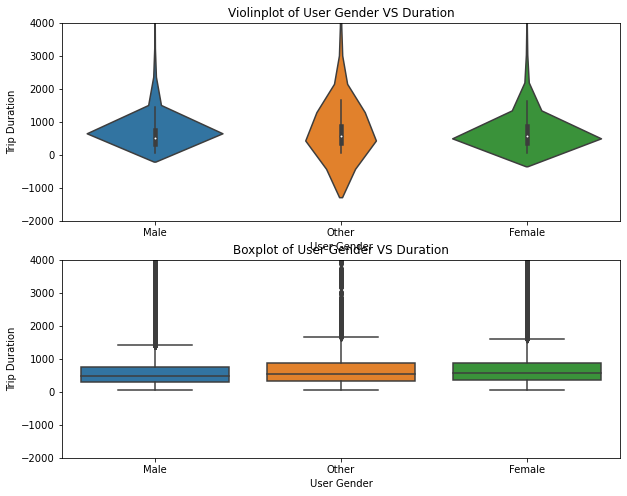

```python
fig, ax = plt.subplots(2, 1, figsize=(10, 8))
sb.violinplot(ax = ax[0], data=df, x='member_gender', y='duration_sec');
ax[0].set_ylim((-2000, 4000))
ax[0].set_xlabel("User Gender")
ax[0].set_ylabel("Trip Duration")
ax[0].set_title("Violinplot of User Gender VS Duration")

sb.boxplot(ax = ax[1], data=df, x='member_gender', y='duration_sec');
ax[1].set_ylim((-2000, 4000))
ax[1].set_xlabel("User Gender")
ax[1].set_ylabel("Trip Duration")
ax[1].set_title("Boxplot of User Gender VS Duration");
```

#### We can see that on averageof the 3 types is almost the same, but females has the highest trip duration.

## Multivariate Exploration

### Distribution of gender type VS duration in sec

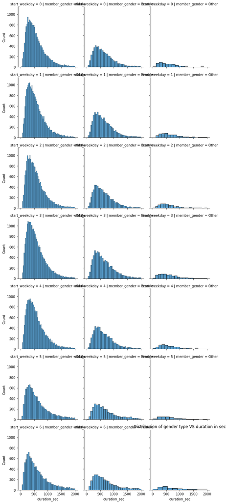

```python
g = sb.FacetGrid(data=df, row='start_weekday',col='member_gender', col_order=['Male', 'Female', 'Other'])
g.map(sb.histplot, 'duration_sec', binrange=(0, 2000));
plt.tight_layout()
plt.title("Distribution of gender type VS duration in sec")
```

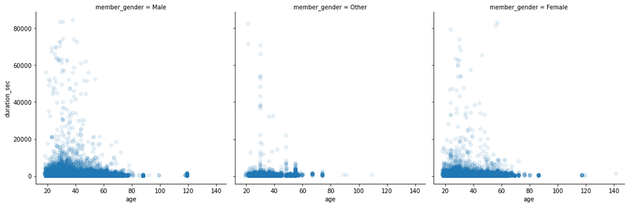

```python
g = sb.FacetGrid(data=df, col='member_gender', col_wrap=3, height=5);
g.map(plt.scatter, 'age', 'duration_sec', alpha=0.1);
```

#### We saw that the most of the data is btween (0, 80) in the x-axis and (0, 5000) on the y-axis, so we must create this plot

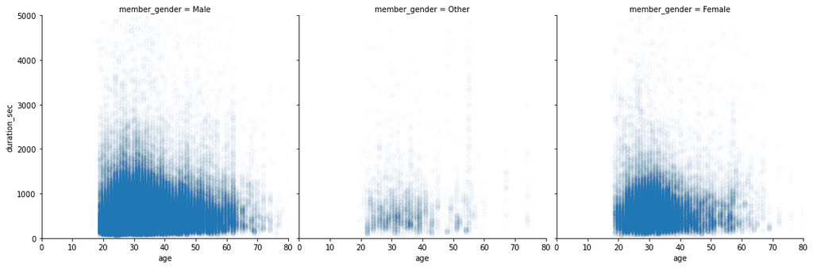

```python
g = sb.FacetGrid(data=df, col='member_gender', col_wrap=3, height=5);
g.map(plt.scatter, 'age', 'duration_sec', alpha=0.01);
g.set(ylim=(0, 5000), xlim=(0, 80))
```